# Performing differential expression analysis on spatial transcriptomics data with smiDE

Ana Gabriela Vasconcelos

2025-01-31

# Introduction

Here we demonstrate use of the smiDE package to analyze spatial transcriptomics data. We’ll use the package’s `small_nsclc` dataset, a small and computationally convenient excerpt of the [CosMx NSCLC (non-small cell lung cancer) dataset](https://nanostring.com/products/cosmx-spatial-molecular-imager/ffpe-dataset/nsclc-ffpe-dataset/). We’ll show all the major modeling approached implemented within the package.

## Quick start

A typical analysis would proceed as follows. Assuming we have a count matrix `cts`, that is normalized by `totalcounts` to obtain matrix `norm`. The metadata matrix `metainfo` contains information for each cell, such as `cell_type`, `niche`, and information of each sample `Run_Tissue_name` if available. Then we would first filter out implausible genes (using `overlap_ratio_metric`). Then we identify neighboring cells with `pre_de`, which will be adjusted for when obtaining DE results with `smi_de`, with the adequate `spatial_model` defined.

```r
totalcounts_scalefactors <- mean(metainfo[["totalcounts"]]) / metainfo[["totalcounts"]]
names(totalcounts_scalefactors) <- metainfo[["cell_ID"]]
norm <- cts %*% Matrix::Diagonal(x=totalcounts_scalefactors, names=TRUE)


overlap_metrics <-
overlap_ratio_metric(assay_matrix = norm,
                           metadata = metainfo,
                           cluster_col = "cell_type",
                           radius = 0.05,
                           split_neighbors_by_colname = "Run_Tissue_name",
                           sdimx_col = "sdimx",
                           sdimy_col = "sdimy"
                           )


pre_de_obj <-
  pre_de(metadata = metainfo
         ,cell_type_metadata_colname = "cell_type"
         ,split_neighbors_by_colname = "tissue"
         ,mm_radius = 0.05
         ,sdimx_colname = "sdimx"
         ,sdimy_colname = "sdimy"
         ,verbose=TRUE
  )


de_obj  <-
smi_de(assay_matrix = cts
           ,metadata = metainfo
           ,formula = ~RankNorm(otherct_expr) + niche + offset(log(totalcounts))
           ,pre_de_obj = pre_de_obj
           ,neighbor_expr_cell_type_metadata_colname = "cell_type"
           ,neighbor_expr_overlap_weight_colname = 'weight'
           ,neighbor_expr_overlap_agg ="sum"
           ,neighbor_expr_totalcount_normalize = TRUE
           ,neighbor_expr_totalcount_scalefactor = totalcounts_scalefactors
           ,family="nbinom2"
           ,spatial_model = list(
             name = "GP_Matern"
             ,k_prop_n = 0.25
             ,x_coord_col = "sdimx"
             ,y_coord_col = "sdimy"
             ,split_neighbors_by_colname = "Run_Tissue_name"
             ,spatial_random_effect = ~Matern(1 | sdimx_cluster + sdimy_cluster %in% Run_Tissue_name)
           )
    )

results(de_obj, "one.vs.rest", variable="niche")
results(de_obj, "spatial_random_effect")
```

## Input data

To perform analysis there are two main objects: a count matrix and meta data information. In the meta data matrix we have information of each sample (`Run_Tissue_name`) and of each individual cell, such as `cell_type`, spatial region (`niche`), two dimensional spatial information (`sdimx` and `sdimy`). For the count matrix we have count for each gene and cell, the value in the $i$-th row and $j$-th columns gives the number of reads for gene $i$ on cell $j$.

```r
# Loading packages
library(data.table)
library(cowplot)
library(smiDE)
library(INLA)
library(Seurat)
library(ggrepel)
library(pals)

# Reading Seurat object
datadir<-system.file("extdata", package="smiDE")
sem <- readRDS(paste0(datadir, "/small_nsclc.rds"))
str(sem, max.level = 3)
```

```
## Formal class 'Seurat' [package "SeuratObject"] with 13 slots
##   ..@ assays      :List of 1
##   .. ..$ RNA:Formal class 'Assay' [package "SeuratObject"] with 8 slots
##   ..@ meta.data   :'data.frame': 116002 obs. of  39 variables:
##   .. ..$ orig.ident                 : Factor w/ 1 level "c": 1 1 1 1 1 1 1 1 1 1 ...
##   .. ..$ nCount_RNA                 : num [1:116002] 5 2 22 20 8 8 7 34 10 9 ...
##   .. ..$ nFeature_RNA               : int [1:116002] 2 1 7 4 1 2 2 4 4 4 ...
##   .. ..$ cell_ID                    : chr [1:116002] "c_3_11_1" "c_3_11_2" "c_3_11_3" "c_3_11_4" ...
##   .. ..$ fov                        : num [1:116002] 11 11 11 11 11 11 11 11 11 11 ...
##   .. ..$ Area                       : int [1:116002] 4513 1372 5910 2707 2913 2514 1348 5897 1929 2237 ...
##   .. ..$ AspectRatio                : num [1:116002] 2.08 1.26 1.23 1.13 1.44 2.12 1.56 0.84 0.96 1.09 ...
##   .. ..$ Width                      : int [1:116002] 106 48 91 62 78 87 56 76 54 59 ...
##   .. ..$ Height                     : int [1:116002] 51 38 74 55 54 41 36 90 56 54 ...
##   .. ..$ Mean.CD298                 : int [1:116002] 3730 2767 3492 7857 6377 10937 3578 3301 2578 3282 ...
##   .. ..$ Max.CD298                  : int [1:116002] 14166 5021 11991 17573 14597 27936 6138 11125 10541 5942 ...
##   .. ..$ Mean.G                     : int [1:116002] 11256 329 1035 879 2556 1138 373 640 432 392 ...
##   .. ..$ Max.G                      : int [1:116002] 47920 833 18621 4218 34554 7309 788 2140 832 736 ...
##   .. ..$ Mean.Y                     : int [1:116002] 370 349 519 497 553 486 342 427 422 485 ...
##   .. ..$ Max.Y                      : int [1:116002] 3837 1090 1677 954 1914 1299 871 1453 2835 1152 ...
##   .. ..$ Mean.R                     : int [1:116002] 0 0 0 0 0 0 0 0 0 0 ...
##   .. ..$ Max.R                      : int [1:116002] 11 0 0 0 77 0 0 29 0 29 ...
##   .. ..$ Mean.DAPI                  : int [1:116002] 3212 6829 3991 1445 2710 253 6296 4189 6968 19097 ...
##   .. ..$ Max.DAPI                   : int [1:116002] 19299 22439 24530 20640 21214 10186 33133 33487 29221 39342 ...
##   .. ..$ dualfiles                  : chr [1:116002] "?" "?" "?" "?" ...
##   .. ..$ Slide_name                 : chr [1:116002] "Lung5-5" "Lung5-5" "Lung5-5" "Lung5-5" ...
##   .. ..$ tissue                     : chr [1:116002] "Lung5-5" "Lung5-5" "Lung5-5" "Lung5-5" ...
##   .. ..$ Run_name                   : chr [1:116002] "Run1050" "Run1050" "Run1050" "Run1050" ...
##   .. ..$ ISH.concentration          : chr [1:116002] "1nM" "1nM" "1nM" "1nM" ...
##   .. ..$ Dash                       : chr [1:116002] "D3" "D3" "D3" "D3" ...
##   .. ..$ slide_ID_numeric           : int [1:116002] 3 3 3 3 3 3 3 3 3 3 ...
##   .. ..$ Run_Tissue_name            : chr [1:116002] "Lung5_Rep3" "Lung5_Rep3" "Lung5_Rep3" "Lung5_Rep3" ...
##   .. ..$ Panel                      : chr [1:116002] "980p" "980p" "980p" "980p" ...
##   .. ..$ Diversity                  : int [1:116002] 114 52 194 70 66 53 32 155 90 100 ...
##   .. ..$ totalcounts                : num [1:116002] 184 82 467 165 135 89 58 336 146 252 ...
##   .. ..$ log10totalcounts           : num [1:116002] 2.26 1.91 2.67 2.22 2.13 ...
##   .. ..$ background                 : num [1:116002] 0.0396 0.0177 0.1006 0.0356 0.0291 ...
##   .. ..$ remove_flagged_cells       : logi [1:116002] FALSE FALSE FALSE FALSE FALSE FALSE ...
##   .. ..$ patient                    : chr [1:116002] "Lung5" "Lung5" "Lung5" "Lung5" ...
##   .. ..$ cell_type                  : chr [1:116002] "epithelial" "plasmablast" "mDC" "plasmablast" ...
##   .. ..$ niche                      : chr [1:116002] "tumor-stroma boundary" "plasmablast-enriched stroma" "plasmablast-enriched stroma" "plasmablast-enriched stroma" ...
##   .. ..$ prop_tumor_in_100_neighbors: num [1:116002] 0.5 0.14 0 0 0 0.02 0 0 0 0 ...
##   .. ..$ sdimx                      : num [1:116002] 14.4 14.5 14.5 14.6 14.6 ...
##   .. ..$ sdimy                      : num [1:116002] -17.7 -17.7 -17.7 -17.7 -17.7 ...
##   ..@ active.assay: chr "RNA"
##   ..@ active.ident: Factor w/ 1 level "c": 1 1 1 1 1 1 1 1 1 1 ...
##   .. ..- attr(*, "names")= chr [1:116002] "c_3_11_1" "c_3_11_2" "c_3_11_3" "c_3_11_4" ...
##   ..@ graphs      : list()
##   ..@ neighbors   : list()
##   ..@ reductions  : list()
##   ..@ images      : list()
##   ..@ project.name: chr "SeuratProject"
##   ..@ misc        : list()
##   ..@ version     :Classes 'package_version', 'numeric_version'  hidden list of 1
##   .. ..$ : int [1:3] 5 0 1
##   ..@ commands    : list()
##   ..@ tools       : list()
```

```r
sem <- subset(sem, Run_Tissue_name=="Lung5_Rep3")

# Meta data from cells
metainfo <- data.table(sem@meta.data)
str(metainfo)
```

```
## Classes 'data.table' and 'data.frame':   50598 obs. of  39 variables:
##  $ orig.ident                 : Factor w/ 1 level "c": 1 1 1 1 1 1 1 1 1 1 ...
##  $ nCount_RNA                 : num  5 2 22 20 8 8 7 34 10 9 ...
##  $ nFeature_RNA               : int  2 1 7 4 1 2 2 4 4 4 ...
##  $ cell_ID                    : chr  "c_3_11_1" "c_3_11_2" "c_3_11_3" "c_3_11_4" ...
##  $ fov                        : num  11 11 11 11 11 11 11 11 11 11 ...
##  $ Area                       : int  4513 1372 5910 2707 2913 2514 1348 5897 1929 2237 ...
##  $ AspectRatio                : num  2.08 1.26 1.23 1.13 1.44 2.12 1.56 0.84 0.96 1.09 ...
##  $ Width                      : int  106 48 91 62 78 87 56 76 54 59 ...
##  $ Height                     : int  51 38 74 55 54 41 36 90 56 54 ...
##  $ Mean.CD298                 : int  3730 2767 3492 7857 6377 10937 3578 3301 2578 3282 ...
##  $ Max.CD298                  : int  14166 5021 11991 17573 14597 27936 6138 11125 10541 5942 ...
##  $ Mean.G                     : int  11256 329 1035 879 2556 1138 373 640 432 392 ...
##  $ Max.G                      : int  47920 833 18621 4218 34554 7309 788 2140 832 736 ...
##  $ Mean.Y                     : int  370 349 519 497 553 486 342 427 422 485 ...
```

[output cut: 26 more lines]

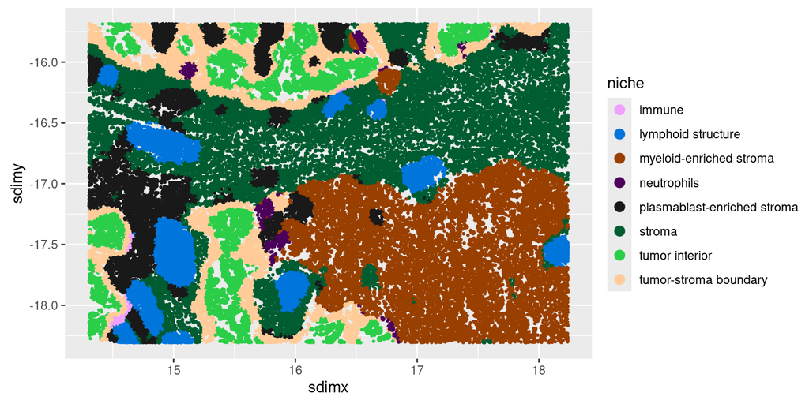

```r
metainfo[grep("tumor", metainfo$cell_type),"cell_type"] <- "tumor"

# Niches from lung 5 patient
ggplot(metainfo, aes(x = sdimx,y = sdimy, col = niche) ) +
  geom_point(cex=0.5) + coord_fixed() +
  scale_color_manual(values=unname(pals::alphabet())) +
  guides(color = guide_legend(override.aes = list(size = 3) ) ) +
  theme(legend.margin = margin(0, 0, 0, 0))
```

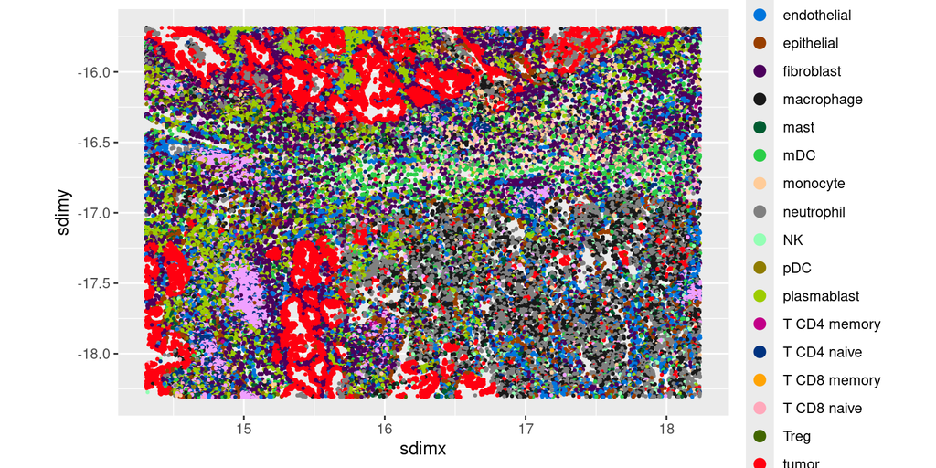

```r
# Cell types from lung 5 patient
ggplot(metainfo, aes(x = sdimx,y = sdimy, col = cell_type) ) +
  geom_point(cex=0.5) + coord_fixed() +
  scale_color_manual(values=unname(pals::alphabet())) +
  guides(color = guide_legend(override.aes = list(size = 3) ) ) +
  theme(legend.margin = margin(0, 0, 0, 0))
```

DE analysis adjusting for spatial information is performed separately for each sample. So for this vignette we will focus on Lung 5 rep 3, with the interest to analyse difference in expression between macrophages cells in each niche.

```r
# Selecting data from macrophage cells
modeldat <- metainfo[cell_type == "macrophage",]
```

## Dealing with cell overlap and segmentation errors

Cell segmentation errors can be a great nuisance which can distort cell-type specific DE results. In practice, even minor errors can cause false positive DE findings. There are two main ways to deal with this: filtering out genes before DE analysis which may be falsely expressed primarily due to cell overlap in the cell type we want to analyze. The `overlap_ratio_metric` function calculates average expression in each celltype, and the average expression in the cells which *neighbor* that cell type within a specified radius. We may choose to pre-filter genes from an analysis which are more expressed in a cell type’s neighbors than they are in the cell type itself.

```r
overlap_metrics <-
overlap_ratio_metric(assay_matrix = sem[["RNA"]]@data,
                           metadata = metainfo,
                           cluster_col = "cell_type",
                           radius = 0.05,
                           split_neighbors_by_colname = "Run_Tissue_name",
                           sdimx_col = "sdimx",
                           sdimy_col = "sdimy"
                           )
overlap_metrics[cell_type=="macrophage"][order(ratio)][]
```

```
##       target avg_neighbor_othercluster avg_cluster  cell_type  all_data
##  1:     C1QC                 0.4156119   4.3956434 macrophage all_cells
##  2:     CD14                 0.2268565   1.4582067 macrophage all_cells
##  3: HLA-DQA1                 0.4204226   2.0030395 macrophage all_cells
##  4:     SPP1                 0.1187093   0.5362209 macrophage all_cells
##  5:    HLA-E                 0.7974496   1.4865755 macrophage all_cells
##  6:      VIM                 0.8598089   1.5547112 macrophage all_cells
##  7:     TYK2                 2.8993044   3.0314083 macrophage all_cells
##  8:      FN1                 1.2265230   0.3201621 macrophage all_cells
##  9:   COL1A1                 1.7218548   0.3553698 macrophage all_cells
## 10:    TPSB2                 0.7796321   0.1418440 macrophage all_cells
##          ratio
##  1: 0.09455088
##  2: 0.15557225
##  3: 0.20989230
##  4: 0.22138140
##  5: 0.53643396
##  6: 0.55303445
##  7: 0.95642161
##  8: 3.83094352
##  9: 4.84524790
## 10: 5.49640648
```

```r
analysis_genes <- overlap_metrics[cell_type=="macrophage" & ratio <= 1]$target
```

The column `ratio` in the table above is equal to `avg_neighbor_othercluster` / `avg_cluster`. Choosing to filter genes with `ratio > 1`, we may remove FN1, COL1A1, and TPSB2 from our analysis.

Further, we can adjust for potential segmentation error with the regression model, by controlling for the expression of a gene within each cell’s neighbors of different cell types. The `pre_de` function identifies neighbors of each cell within a specified radius and records their cell types, so that this covariate can be computed and used within model fitting. Below, we use the ‘totalcounts’ in each cell to create a totalcount normalized dataset for gaussian regression models; we’ll also pass these normalization / scaling factors to smiDE to use for computing our covariate for constructing our cell overlap covariate.

```r
# Pre DE object
pre_de_obj <-
  pre_de(metadata = metainfo
         ,cell_type_metadata_colname = "cell_type"
         ,split_neighbors_by_colname = "tissue"
         ,mm_radius = 0.05
         ,sdimx_colname = "sdimx"
         ,sdimy_colname = "sdimy"
         ,verbose=TRUE
  )
pre_de_obj$cell_adjacency_dt[]
```

```
##                   to        from sdimx_begin sdimy_begin sdimx_end sdimy_end
##       1:    c_3_11_1    c_3_11_1    14.38246   -17.65750  14.38246 -17.65750
##       2:    c_3_11_1   c_3_11_15    14.33908   -17.65786  14.38246 -17.65750
##       3:    c_3_11_1   c_3_11_59    14.34340   -17.67136  14.38246 -17.65750
##       4:    c_3_11_1   c_3_11_65    14.35744   -17.66866  14.38246 -17.65750
##       5:    c_3_11_1   c_3_11_66    14.36932   -17.66866  14.38246 -17.65750
##      ---
## 1161474: c_3_29_2928 c_3_29_2931    17.60080   -16.33450  17.58028 -16.33396
## 1161475: c_3_29_2929 c_3_29_2929    18.21658   -16.33486  18.21658 -16.33486
## 1161476: c_3_29_2930 c_3_29_2930    17.54374   -16.33468  17.54374 -16.33468
## 1161477: c_3_29_2931 c_3_29_2931    17.60080   -16.33450  17.60080 -16.33450
## 1161478: c_3_29_2932 c_3_29_2932    17.83462   -16.33504  17.83462 -16.33504
##            distance   weight tissue_from tissue_to cell_type_from cell_type_to
##       1: 0.00000000      Inf     Lung5-5   Lung5-5     epithelial   epithelial
##       2: 0.04338149 23.05130     Lung5-5   Lung5-5           mast   epithelial
##       3: 0.04144615 24.12769     Lung5-5   Lung5-5     epithelial   epithelial
##       4: 0.02739609 36.50155     Lung5-5   Lung5-5    endothelial   epithelial
##       5: 0.01723964 58.00585     Lung5-5   Lung5-5     epithelial   epithelial
##      ---
## 1161474: 0.02052710 48.71608     Lung5-5   Lung5-5            mDC   fibroblast
## 1161475: 0.00000000      Inf     Lung5-5   Lung5-5           mast         mast
## 1161476: 0.00000000      Inf     Lung5-5   Lung5-5     fibroblast   fibroblast
## 1161477: 0.00000000      Inf     Lung5-5   Lung5-5            mDC          mDC
## 1161478: 0.00000000      Inf     Lung5-5   Lung5-5     fibroblast   fibroblast
```

```r
### Normalizing data based on total counts in the cell,
### `totalcounts_scalefactors` later passed to smi_de() for creating "otherct_expr" covariate, normalzing neighbor
### expression by the neighbors 'totalcounts'

totalcounts <- sem@meta.data[["totalcounts"]]
totalcounts_scalefactors <- mean(totalcounts) / totalcounts
names(totalcounts_scalefactors) <- rownames(sem@meta.data)
sem <- Seurat::SetAssayData(sem
                           ,"data"
                           ,sem[["RNA"]]@counts %*% Matrix::Diagonal(x=totalcounts_scalefactors, names=colnames(sem)))
```

# Methods for differential expression

Here we discuss different methods for performing differential expression. Due to the nature of the spatial data it is important to account for the correlation between cells to avoid spatial confounding. That is, cells’ expression can be associated with spatial unknown variables, such as proximity to blood vessels or technical artefacts for example, and because of that we could consider that there’s difference in expression between niches when it is actually due to some other factor unrelated to that. To deal with spatial confounding a common way is to model cell correlation using a Gaussian process.

Let $y_{ig}$ be the transcript counts of the $g$th gene ($g=1,\dots,p$) on the $i$th cell ($i=1,\dots,n$). Then for each gene $g$ we model the conditional mean $\mu_g$ of $y_g=(y_{1g},\dots,y_{ng})$ as

$$\begin{equation}\label{eqn:mu}
g(\mu_g) = Z\alpha + X\beta + b ,
\end{equation}$$

where $g$ is a link function, either the identity for Gaussian distribution, or log function for Negative Binomial. The vector $X$ represents the covariate of interest, with $\beta$ the DE effect sizes associated with it, and $Z$ represents the covariates to be adjusted for, for example the spatially lagged expression vectors $l_1,\dots,l_p$, with $\alpha$ the coefficients associated with it. The random component $b$ is assumed to have mean zero and covariance matrix $\Sigma$, which describes the correlation between cells. For a Gaussian Process we assume $\Sigma$ is a Matern matrix.

An important aspect of spatial single cell transcriptomics data is the large number of cells assayed, often reaching hundreds of thousands or even millions of cells per subject. Modeling the correlation between these cells thus requires dealing with a covariance matrix of extremely large size, which introduces computational challenges. Therefore we implement here approximate approaches to address this challenge. The first one assumes a bayesian approach (*GP INLA*) and the second models correlation between groups of cells instead of individual cells. When modelling correlation of cluster of cells we further have two choices, assume each cluster is independent (*Independent clusters*), or model their correlation with a Matern type matrix (*GP cluster*).

The choice of model depends on the goal of the analysis and the size of the dataset. When running DE for several genes it can take substantial time, specially when there is a high number of cells. Independent clusters is the fastest model to run and it provides good ranking of genes, however it does not maintain control of type 1 error so it is not recommended for inference. Alternatively it is a good alternative for pre screening genes in an exploratory way. GP INLA is the second fastest model, it provides good control of type 1 error and ranking of genes, however it is a bayesian approach thus it does not provide p-values and results depends on the choice or priors. GP clusters processing time and results is directed linked to the number of clusters chosen. Higher number of clusters leads to better control of type 1 error but takes longer to run. It is a frequentist approach thus it provides p-values and doesn’t require prior choices. Below is a table summarizing results for each model.

|  | No spatial | Independent clusters | GP cluster | GP INLA |
| --- | --- | --- | --- | --- |
| **Time** | Very fast | Very fast | Slower | Fast |
| **Type 1 error** | $$>>>\alpha$$ | $>>\alpha$ | $\alpha$ | $\alpha$ |
| **Ranking** | Bad | Good depending on cluster | Good | Good |
| **Cluster suggestion** | - | 5% | 25% | - |
| **Results stability** | Stable | Stable | Stable | Depends on prior |

## No spatial

As discussed it is important to account for the spatial variation, however here we demonstrate how to fit a model without accounting for it, to allow for comparisons later. We can fit either using raw counts and Negative Binomial distribution, or normalized counts and a Gaussian distribution. When fitting the models the arguments that will change is `assay_matrix`, `family` and when fitting a negative binomial we need to specify the offset as `log(totalcounts)`. For the `neighborhood_counts` we specify the object obtained from the `pre_de` function. The `formula` argument gives the fixed effects formula to be used in the `lm` function. It contains the variable `otherct_expr` which along side with `RankNorm` adjusts for cell overlap. The `groupVar` indicated which variable is of interest for DE analysis.

```r
num_genes <- length(analysis_genes)

# Negative Binomial
de_nospatial_nb <-
   smi_de(assay_matrix = sem[["RNA"]]@counts
          ,metadata = modeldat
          ,formula = ~RankNorm(otherct_expr) + niche + offset(log(totalcounts))
          ,pre_de_obj = pre_de_obj
          ,neighbor_expr_cell_type_metadata_colname = "cell_type"
          ,neighbor_expr_overlap_agg ="sum"
          ,neighbor_expr_totalcount_normalize = TRUE
          ,neighbor_expr_totalcount_scalefactor = totalcounts_scalefactors
          ,family="nbinom2"
          ,targets=analysis_genes
   )

# Gaussian
de_nospatial_gau <-
  smiDE::smi_de(assay_matrix = sem[["RNA"]]@data ## using 'totalcount normalized' data
                ,metadata = modeldat
                ,formula = ~RankNorm(otherct_expr) + niche
                ,pre_de_obj = pre_de_obj
                ,neighbor_expr_cell_type_metadata_colname = "cell_type"
                ,neighbor_expr_overlap_agg ="sum"
                ,neighbor_expr_totalcount_normalize = TRUE
                ,neighbor_expr_totalcount_scalefactor = totalcounts_scalefactors
                ,targets= analysis_genes
                ,family = "gaussian"
                )
```

We can access the results from each model with the `results` function. When comparing multiple niches it gives the options to access `pairwise`, `one.vs.rest`, `one.vs.all`, `emmeans` and `model_summary`. We specify `variable = "niche"` since it is the variable of interest.

```r
# Negative Binomial
str(results(de_nospatial_nb), max.level = 1)
```

```
## List of 6
##  $ pairwise             :Classes 'data.table' and 'data.frame':  203 obs. of  18 variables:
##   ..- attr(*, ".internal.selfref")=<externalptr>
##  $ one.vs.rest          :Classes 'data.table' and 'data.frame':  56 obs. of  18 variables:
##   ..- attr(*, ".internal.selfref")=<externalptr>
##  $ one.vs.all           :Classes 'data.table' and 'data.frame':  56 obs. of  18 variables:
##   ..- attr(*, ".internal.selfref")=<externalptr>
##  $ emmeans              :Classes 'data.table' and 'data.frame':  70 obs. of  11 variables:
##   ..- attr(*, ".internal.selfref")=<externalptr>
##  $ model_summary        :Classes 'data.table' and 'data.frame':  77 obs. of  11 variables:
##   ..- attr(*, ".internal.selfref")=<externalptr>
##  $ spatial_random_effect:Classes 'data.table' and 'data.frame':  0 obs. of  0 variables
##   ..- attr(*, ".internal.selfref")=<externalptr>
```

```r
results(de_nospatial_nb, variable = "niche")$pairwise[contrast == "plasmablast-enriched stroma / tumor-stroma boundary",]
```

```
##                                               contrast     ratio         SE  df
## 1: plasmablast-enriched stroma / tumor-stroma boundary 1.0520246 0.09265640 Inf
## 2: plasmablast-enriched stroma / tumor-stroma boundary 1.1081689 0.13568263 Inf
## 3: plasmablast-enriched stroma / tumor-stroma boundary 1.5741232 0.18237309 Inf
## 4: plasmablast-enriched stroma / tumor-stroma boundary 1.0980986 0.12389538 Inf
## 5: plasmablast-enriched stroma / tumor-stroma boundary 0.3501360 0.12508573 Inf
## 6: plasmablast-enriched stroma / tumor-stroma boundary 0.9655248 0.08108316 Inf
## 7: plasmablast-enriched stroma / tumor-stroma boundary 0.6054326 0.07291530 Inf
##    null    z.ratio      p.value fold_change modelest_cpc_1 modelest_cpc_2
## 1:    1  0.5758370 5.647253e-01   1.0520246      3.3710131      3.2043102
## 2:    1  0.8388618 4.015468e-01   1.1081689      1.5937870      1.4382166
## 3:    1  3.9160228 9.002176e-05   1.5741232      2.2158454      1.4076697
## 4:    1  0.8294115 4.068716e-01   1.0980986      1.3945159      1.2699368
## 5:    1 -2.9375413 3.308261e-03   0.3501360      0.2480294      0.7083802
## 6:    1 -0.4177679 6.761168e-01   0.9655248      2.2228077      2.3021756
## 7:    1 -4.1666615 3.090930e-05   0.6054326      1.1902254      1.9659091
##    counts_1  propnz_1 ncells_1 counts_2  propnz_2 ncells_2  term   target
## 1:      826 0.8028169      213      509 0.6666667      168 niche     C1QC
## 2:      430 0.6384977      213      254 0.5714286      168 niche     CD14
## 3:      565 0.6901408      213      224 0.5178571      168 niche HLA-DQA1
## 4:      332 0.6009390      213      203 0.4761905      168 niche    HLA-E
## 5:       82 0.1079812      213      201 0.2559524      168 niche     SPP1
## 6:      954 0.8450704      213      553 0.7857143      168 niche     TYK2
## 7:      303 0.5492958      213      325 0.6071429      168 niche      VIM
```

```r
# Gaussian
results(de_nospatial_gau, variable = "niche")$pairwise[contrast == "plasmablast-enriched stroma - tumor-stroma boundary",]
```

```
##                                               contrast   estimate        SE
## 1: plasmablast-enriched stroma - tumor-stroma boundary  0.2325108 0.4165280
## 2: plasmablast-enriched stroma - tumor-stroma boundary  0.2037018 0.1952067
## 3: plasmablast-enriched stroma - tumor-stroma boundary  0.9025381 0.2826066
## 4: plasmablast-enriched stroma - tumor-stroma boundary  0.1754440 0.2232827
## 5: plasmablast-enriched stroma - tumor-stroma boundary -0.7678277 0.2111023
## 6: plasmablast-enriched stroma - tumor-stroma boundary  0.2084583 0.3262914
## 7: plasmablast-enriched stroma - tumor-stroma boundary -0.9781105 0.2382210
##      df    t.ratio      p.value fold_change modelest_cpc_1 modelest_cpc_2
## 1: 3939  0.5582118 5.767315e-01   1.0767758      3.2609514       3.028441
## 2: 3939  1.0435186 2.967722e-01   1.1446321      1.6121154       1.408414
## 3: 3939  3.1936198 1.416082e-03   1.6086657      2.3853522       1.482814
## 4: 3939  0.7857481 4.320623e-01   1.1478288      1.3622488       1.186805
## 5: 3939 -3.6372304 2.791135e-04   0.2861410      0.3077737       1.075601
## 6: 3939  0.6388716 5.229436e-01   1.0681652      3.2665903       3.058132
## 7: 3939 -4.1058950 4.109211e-05   0.5335602      1.1188599       2.096970
##     counts_1  propnz_1 ncells_1 counts_2  propnz_2 ncells_2  term   target
## 1: 694.82963 0.8028169      213 497.7337 0.6666667      168 niche     C1QC
## 2: 363.55044 0.6384977      213 253.6819 0.5714286      168 niche     CD14
## 3: 528.67412 0.6901408      213 248.1032 0.5178571      168 niche HLA-DQA1
## 4: 291.91694 0.6009390      213 192.7296 0.4761905      168 niche    HLA-E
## 5:  61.70758 0.1079812      213 182.1979 0.2559524      168 niche     SPP1
## 6: 867.08055 0.8450704      213 605.2522 0.7857143      168 niche     TYK2
## 7: 250.18702 0.5492958      213 355.5685 0.6071429      168 niche      VIM
```

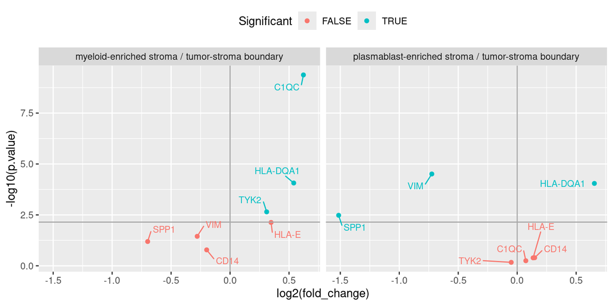

```r
pairwise_res <- results(de_nospatial_nb, variable="niche")$pairwise[contrast %in% c("plasmablast-enriched stroma / tumor-stroma boundary",
                        "myeloid-enriched stroma / tumor-stroma boundary")]
pairwise_res[,sign:=ifelse(p.value < 0.05/num_genes, TRUE, FALSE)]
ggplot(pairwise_res, aes(x = log2(fold_change), y = -log10(p.value),
             col = as.factor(sign), label = target)) +
  geom_point() + facet_wrap(contrast~.)+
  geom_hline(yintercept = -log10(0.05/num_genes), col = "darkgrey")+
  geom_vline(xintercept = 0, col = "darkgrey")+
  geom_text_repel(show.legend = F, box.padding = 0.5, cex = 3) +
  labs(color = "Significant") +
  theme(legend.position = "top")
```

## GP clusters

To fit models that account for spatial correlation we use similar arguments as before, with an additional `spatial_model` argument. Using a Gaussian Process may take longer to run, so to expedite processing time we model correlation between cluster of cells obtained based on their spatial location. We have to make a decision on the number of clusters to be considered, ideally we would model the correlation of individual cells, so we want to consider a large number of clusters. However as the number of clusters increase so does the computational time. Below we see some examples of clustering data with function `xy_kmeans_clusters`, either based on a proportion of total number of cells, with `k_prop_n`, or by directly choosing the number of clusters `k`.

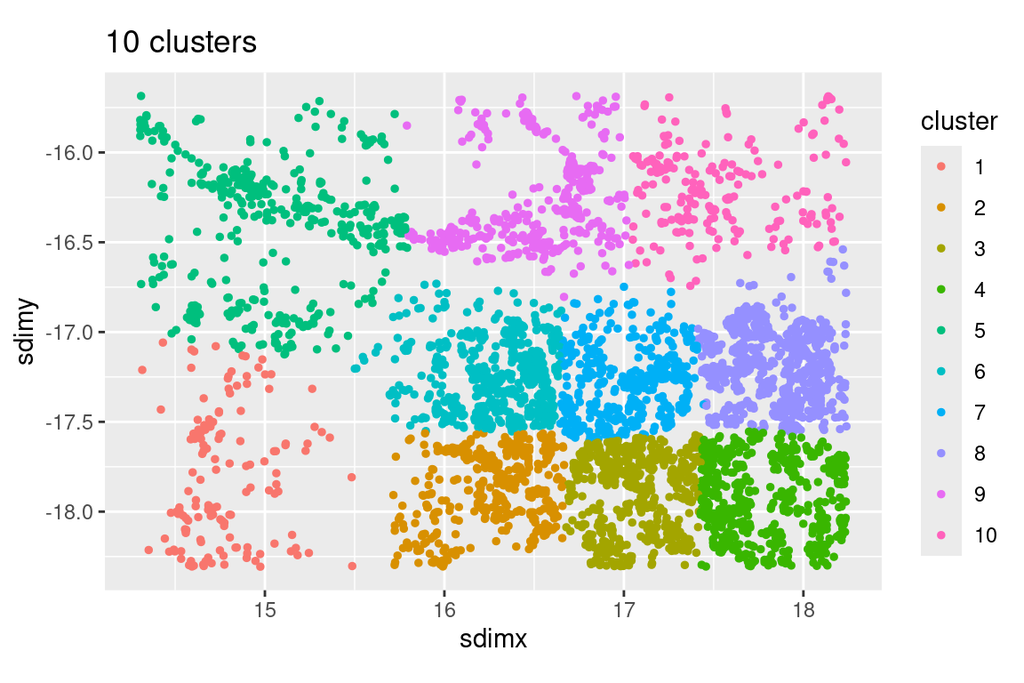

```r
# 10 clusters
clusters10 <-
smiDE::xy_kmeans_clusters(modeldat, k = 10,
                          split_neighbors_by_colname = "Run_Tissue_name")
ggplot(clusters10, aes(sdimx, sdimy, color=factor(k_cluster))) +
  geom_point(cex = 1) + labs(col = "cluster") +
  coord_fixed()+
  ggtitle("10 clusters")
```

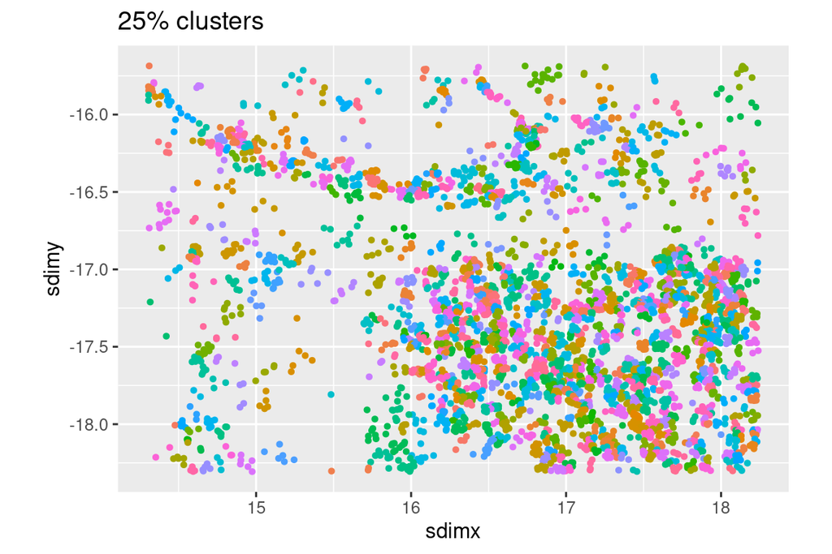

```r
# 25% clusters
clusters_prop_25 <-
smiDE::xy_kmeans_clusters(modeldat, k_prop_n = 0.25,
                          split_neighbors_by_colname = "Run_Tissue_name")

ggplot(clusters_prop_25, aes(sdimx, sdimy, color=factor(k_cluster))) +
  geom_point(cex = 1) + labs(col = "cluster") +
  scale_color_manual(values = sample(scales::hue_pal()(2776))) +
  coord_fixed()+
  ggtitle("25% clusters")+
  theme(legend.position = "none")
```

A recommended cluster size corresponds to 25% of the sample size, but this number can be adjusted based on the specific dataset. If there’s not a large number of cells in such way that computational time is not a problem we can increase this percentage, if there’s a very high number of cells and we need computation to be faster we can decrease this percentage, however keep in mind that this can lead to more false positives. When performing DE analysis there’s no need to obtain clusters previously, `smi_de` will calculate internally based on the number of clusters with either `k_prop_n` or `k` in the `spatial_model` argument, alongside with `GP_Matern`. For the following examples we will assume a Negative Binomial distribution for comparison.

```r
de_GPclust_nb  <-
smi_de(assay_matrix = sem[["RNA"]]@counts
           ,metadata = modeldat
           ,formula = ~RankNorm(otherct_expr) + niche + offset(log(totalcounts))
           ,pre_de_obj = pre_de_obj
           ,neighbor_expr_cell_type_metadata_colname = "cell_type"
           ,neighbor_expr_overlap_agg ="sum"
           ,neighbor_expr_totalcount_normalize = TRUE
           ,neighbor_expr_totalcount_scalefactor = totalcounts_scalefactors
           ,family="nbinom2"
       ,targets = analysis_genes
           ,spatial_model = list(
             name = "GP_Matern"
             ,k_prop_n = 0.25
             ,x_coord_col = "sdimx"
             ,y_coord_col = "sdimy"
             ,spatial_random_effect =  ~Matern(1 | sdimx_cluster + sdimy_cluster)
           )
       ,nCores = 4
    )
```

```r
# pairwise results GP cluster
results_GPclust_nb <- results(de_GPclust_nb, variable="niche")$pairwise
results_GPclust_nb[contrast == "plasmablast-enriched stroma / tumor-stroma boundary"][order(abs(p.value))]
```

```
##                                               contrast     ratio         SE  df
## 1: plasmablast-enriched stroma / tumor-stroma boundary 1.4557873 0.18822947 Inf
## 2: plasmablast-enriched stroma / tumor-stroma boundary 0.3341945 0.12825767 Inf
## 3: plasmablast-enriched stroma / tumor-stroma boundary 0.6953851 0.09363391 Inf
## 4: plasmablast-enriched stroma / tumor-stroma boundary 1.2048663 0.15038248 Inf
## 5: plasmablast-enriched stroma / tumor-stroma boundary 1.1612896 0.16463403 Inf
## 6: plasmablast-enriched stroma / tumor-stroma boundary 1.0599442 0.10395476 Inf
## 7: plasmablast-enriched stroma / tumor-stroma boundary 0.9668575 0.09408327 Inf
##    null    z.ratio     p.value fold_change modelest_cpc_1 modelest_cpc_2
## 1:    1  2.9045206 0.003678161   1.4557873      2.2835742       1.568618
## 2:    1 -2.8558751 0.004291839   0.3341945      0.1373579       0.411012
## 3:    1 -2.6980194 0.006975339   0.6953851      1.1502414       1.654107
## 4:    1  1.4931873 0.135388159   1.2048663      1.4895169       1.236251
## 5:    1  1.0547573 0.291536344   1.1612896      1.6797070       1.446415
## 6:    1  0.5935851 0.552789630   1.0599442      3.3244245       3.136415
## 7:    1 -0.3463642 0.729069043   0.9668575      2.4230427       2.506101
##    counts_1  propnz_1 ncells_1 counts_2  propnz_2 ncells_2  term   target
## 1:      565 0.6901408      213      224 0.5178571      168 niche HLA-DQA1
## 2:       82 0.1079812      213      201 0.2559524      168 niche     SPP1
## 3:      303 0.5492958      213      325 0.6071429      168 niche      VIM
## 4:      332 0.6009390      213      203 0.4761905      168 niche    HLA-E
## 5:      430 0.6384977      213      254 0.5714286      168 niche     CD14
## 6:      826 0.8028169      213      509 0.6666667      168 niche     C1QC
## 7:      954 0.8450704      213      553 0.7857143      168 niche     TYK2
```

Continuing on the analysis of DE genes between tumor-stroma boundary and plasmablast and myeloid-enriched stroma, we analyze the results using a GP model. Unlike the previous model, we note that when accounting for spatial correlation, genes C1QC, TYK2 and HLA-DQA1 are not down-regulated on macrophages at the tumor-stroma boundary, and VIM is not differently expressed between myeloid-enriched stroma and tumor-stroma boundary.

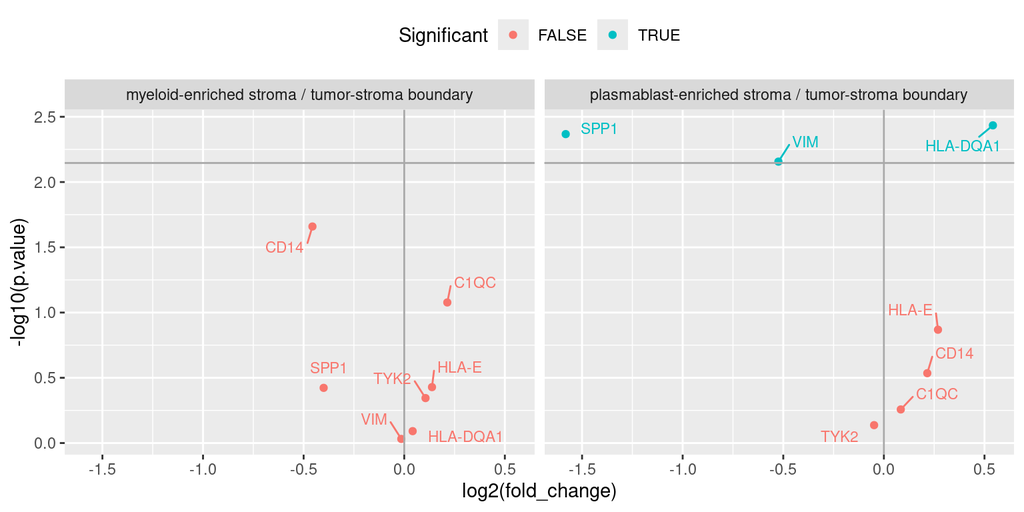

```r
results_GPclust_nb$sign <- ifelse(results_GPclust_nb$p.value < 0.05/num_genes, T, F)

results_GPclust_nb_subset <-
results_GPclust_nb[contrast %in% c("plasmablast-enriched stroma / tumor-stroma boundary",
                        "myeloid-enriched stroma / tumor-stroma boundary")]
ggplot(results_GPclust_nb_subset, aes(x = log2(fold_change), y = -log10(p.value),
             col = as.factor(sign), label = target)) +
  geom_point() + facet_wrap(contrast~.)+
  geom_hline(yintercept = -log10(0.05/num_genes), col = "darkgrey")+
  geom_vline(xintercept = 0, col = "darkgrey")+
  geom_text_repel(show.legend = F, box.padding = 0.5, cex = 3) +
  labs(color = "Significant")+
  theme(legend.position = "top")
```

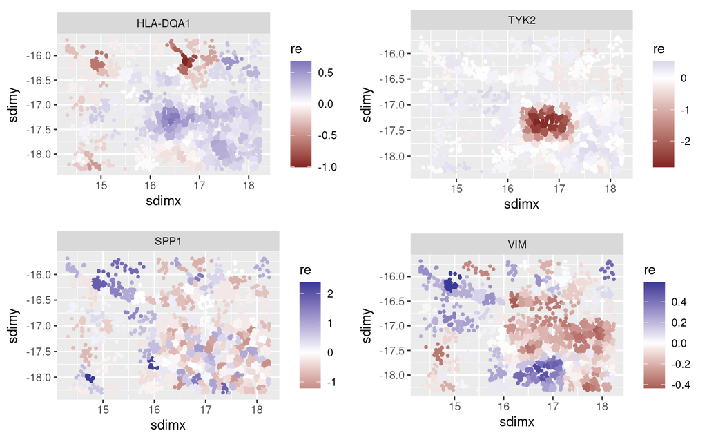

```r
cowplot::plot_grid(plotlist=
  lapply(
    split(results(de_GPclust_nb, targets = c("HLA-DQA1","TYK2", "SPP1", "VIM"))$spatial_random_effect,
          by="target"), function(xx){
  ggplot(xx, aes(sdimx,sdimy, col= re)) +
  geom_point(cex=0.8) +
  scale_color_gradient2(midpoint = 0) +
      theme(legend.position = "right") +
      facet_wrap(~target) +
      coord_fixed()
  }), nrow = 2
)
```

On another note, we compare results obtained with and without adjustment for spatial correlation for the analysis of expression of one niche vs average expression of the rest. The plot below compares -log10(p-values) obtained by each model, with lines indicating bonferroni corrected significance levels, colors indicate genes and points indicate each possible comparison. Note that p-values for no spatial model are much smaller than when accounting for spatial correlation, including several comparisons that are not obtained when adjusting for spatial correlation.

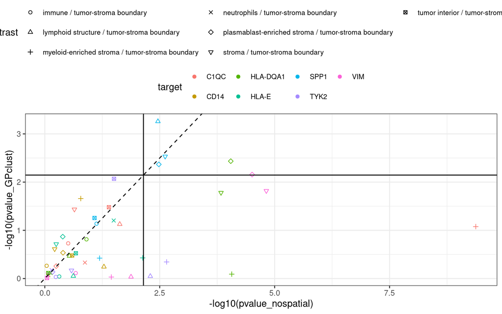

```r
results_nospatial <- results(de_nospatial_nb,
                                  variable="niche")$pairwise[grepl("tumor-stroma boundary", contrast)]
results_GPclust <- results(de_GPclust_nb,
                              variable="niche")$pairwise[grepl("tumor-stroma boundary", contrast)]

compar_nospatial <- merge(results_nospatial[,.(target, contrast,
                                                    est_nospatial = fold_change,
                                                    pvalue_nospatial = p.value)],
                          results_GPclust[,.(target, contrast,
                                                est_GPclust = fold_change,
                                                pvalue_GPclust = p.value)],
                          by=c("contrast", "target"))


ggplot(compar_nospatial,
       aes(x=-log10(pvalue_nospatial), y=-log10(pvalue_GPclust),
           color=target, shape = contrast)) +
  geom_point() + theme_bw() +
  scale_shape_manual(guide = guide_legend(nrow=3),
                     values = c(1:8)) +
  geom_abline(slope=1,intercept=0,lty=2) +
  geom_hline(yintercept = -log10(0.05/num_genes)) +
  geom_vline(xintercept = -log10(0.05/num_genes)) +
   theme(legend.position = "top",
        legend.direction = "horizontal",
        legend.box = "vertical",
        legend.text = element_text(size = 8),
        legend.margin = margin(0, 0, 0, 0))
```

## Independent clusters

Another possibility for modelling spatial variation is using independent clusters. This approach is less successful at controlling false positives, but it may be useful for ranking genes based on their significance. For that we first create the clusters for cells using `xy_kmeans_clusters`. Then pass that as a random effect on the model with `(1|k_cluster)` in the formula. In this case a cluster size of 5% should be use, and inference should not be made on p-values as if may lead to false positives.

```r
modeldat <- smiDE::xy_kmeans_clusters(modeldat, k_prop_n = 0.05, split_neighbors_by_colname = "tissue")
deindep_clusters <-
  smiDE::smi_de(assay_matrix = sem[["RNA"]]@counts
                ,metadata = modeldat
                ,formula = ~RankNorm(otherct_expr) + niche + offset(log(totalcounts)) + (1|k_cluster)
                ,pre_de_obj = pre_de_obj
                ,neighbor_expr_cell_type_metadata_colname = "cell_type"
                ,neighbor_expr_overlap_agg ="sum"
                ,neighbor_expr_totalcount_normalize = TRUE
                ,neighbor_expr_totalcount_scalefactor = totalcounts_scalefactors
                ,family="nbinom2"
                )
```

```r
### one niche vs. cell-weighted average of other niches
results_indep <- results(deindep_clusters, variable="niche")$pairwise
results_indep[contrast == "plasmablast-enriched stroma / tumor-stroma boundary"][order(abs(p.value))]
```

```
##                                                contrast     ratio         SE
##  1: plasmablast-enriched stroma / tumor-stroma boundary 1.5624682 0.20036483
##  2: plasmablast-enriched stroma / tumor-stroma boundary 0.6707108 0.08981653
##  3: plasmablast-enriched stroma / tumor-stroma boundary 0.3490124 0.13131626
##  4: plasmablast-enriched stroma / tumor-stroma boundary 0.5218803 0.13817430
##  5: plasmablast-enriched stroma / tumor-stroma boundary 2.1018198 1.05140097
##  6: plasmablast-enriched stroma / tumor-stroma boundary 1.1486043 0.16397891
##  7: plasmablast-enriched stroma / tumor-stroma boundary 0.8140670 0.18348995
##  8: plasmablast-enriched stroma / tumor-stroma boundary 1.1068830 0.13478132
##  9: plasmablast-enriched stroma / tumor-stroma boundary 1.0424880 0.10309459
## 10: plasmablast-enriched stroma / tumor-stroma boundary 0.9626344 0.09441880
##      df null    z.ratio      p.value fold_change modelest_cpc_1 modelest_cpc_2
##  1: Inf    1  3.4800396 0.0005013396   1.5624682     6.25517974     4.00339660
##  2: Inf    1 -2.9826739 0.0028574228   0.6707108     1.19052417     1.77501853
##  3: Inf    1 -2.7977277 0.0051463473   0.3490124     1.07096267     3.06855218
```

[output cut: 18 more lines]

## GP - INLA

Another approach to account for spatial correlation is by considering a Gaussian Process under a bayesian framework. For that we specify the name `GP_INLA`. This approach has processing time much faster than the frequentist GP, therefore there’s no need to model correlation between cluster of cells like before. Since inference is performed based on credible intervals, to adjust for multiple comparison of genes, one possibility is to adjust the quantiles to correspond to a Bonferroni adjsuted level of significance (0.05/number of genes) by including `quantiles = c(0.025/num_genes, 0.5, 1-0.025/num_genes)` in the list for `spatial_model`.

```r
# Negative Binomial

de_inla_nb <-
  smiDE::smi_de(assay_matrix = sem[["RNA"]]@counts
                ,metadata = modeldat
                ,formula = ~RankNorm(otherct_expr) + niche + offset(log(totalcounts))
                ,groupVar = "niche"
                ,family="nbinom2"
                ,targets = analysis_genes
                ,pre_de_obj = pre_de_obj
                ,neighbor_expr_cell_type_metadata_colname = "cell_type"
                ,neighbor_expr_overlap_agg ="sum"
                ,neighbor_expr_totalcount_normalize = TRUE
                ,neighbor_expr_totalcount_scalefactor = totalcounts_scalefactors
                ,spatial_model = list(name="GP_INLA",
                                     quantiles = c(0.025/num_genes, 0.5, 1-0.025/num_genes)
                                     ,x_coord_col = "sdimx", y_coord_col = "sdimy"
                                     )
                ,nCores=1
  )
```

Once again after fitting the model we can pull out contrasts, model summaries, and emmeans using the `smiDE::results` function. For INLA the point estimate is usually given by the median (`0.5quant`) of the posterior distribution.

```r
# pairwise results GP INLA
results_inla_nb <- results(de_inla_nb, variable="niche")$pairwise
colnames(results_inla_nb)[4:6] <- c("credible_lb","estimate","credible_ub")
results_inla_nb[contrast == "plasmablast-enriched stroma / tumor-stroma boundary"]
```

```
##                                               contrast      mean         sd
## 1: plasmablast-enriched stroma / tumor-stroma boundary 0.9996951 0.09298393
## 2: plasmablast-enriched stroma / tumor-stroma boundary 1.2308526 0.13613563
## 3: plasmablast-enriched stroma / tumor-stroma boundary 1.4393336 0.12647902
## 4: plasmablast-enriched stroma / tumor-stroma boundary 1.1537719 0.12041336
## 5: plasmablast-enriched stroma / tumor-stroma boundary 0.3952731 0.37092607
## 6: plasmablast-enriched stroma / tumor-stroma boundary 1.0137884 0.09360955
## 7: plasmablast-enriched stroma / tumor-stroma boundary 0.7159008 0.12888183
##    credible_lb  estimate credible_ub      mode          kld counts_1  propnz_1
## 1:   0.7784567 0.9996951    1.283810 0.9996951 2.152245e-05      826 0.8028169
## 2:   0.8534122 1.2308526    1.775225 1.2308526 5.010989e-04      430 0.6384977
## 3:   1.0242266 1.4393336    2.022679 1.4393336 2.334803e-04      565 0.6901408
## 4:   0.8345283 1.1537719    1.595141 1.1537719 6.809723e-05      332 0.6009390
## 5:   0.1457285 0.3952731    1.072138 0.3952731 6.341355e-03       82 0.1079812
## 6:   0.7881036 1.0137884    1.304102 1.0137884 3.664057e-05      954 0.8450704
## 7:   0.5061511 0.7159008    1.012571 0.7159008 3.994584e-05      303 0.5492958
##    ncells_1 counts_2  propnz_2 ncells_2  term   target
## 1:      213      509 0.6666667      168 niche     C1QC
## 2:      213      254 0.5714286      168 niche     CD14
## 3:      213      224 0.5178571      168 niche HLA-DQA1
## 4:      213      203 0.4761905      168 niche    HLA-E
## 5:      213      201 0.2559524      168 niche     SPP1
## 6:      213      553 0.7857143      168 niche     TYK2
## 7:      213      325 0.6071429      168 niche      VIM
```

Inference here is performed based on credible intervals, that is, if the credible intervals contain one (or zero when using a Gaussian distribution), then there is not enough evidence of the gene being differently expressed between niches. Note that there are no p-values, so volcano plots can’t be obtained. However we can obtain an ad hoc “bayesian volcano plot”. First we get which genes are significant, based on credible interval. Then, for the x axis, for non significant we plot the point estimate, and for significant we plot the credible interval bound that is closes to 1 (for Negative Binomial), or 0 (for Gaussian). With this we can have an idea on how close each interval is of the null, and know the direction of the effect. For the y axis for non significant we plot 0, and for significant we plot the absolute value of the estimate, to understand which genes have higher effect.

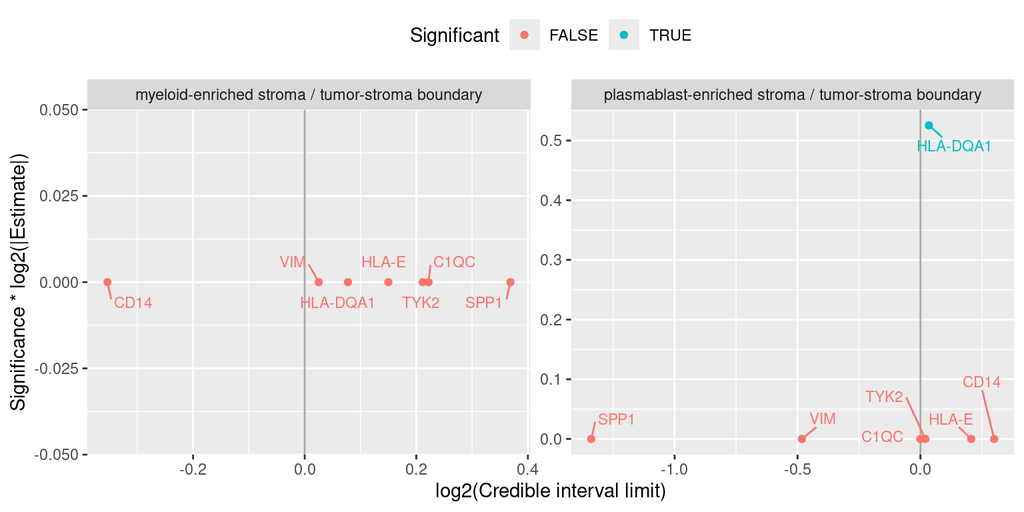

```r
# Creating variable indicating if credible interval contains 1
results_inla_nb$sign <- with(results_inla_nb,
                             ifelse(credible_lb > 1 &  credible_ub > 1 |
                                    credible_lb < 1 &  credible_ub < 1 , 1, 0))

#Creating variable for "bayesian volcano plot"
## gets interval bound closer to 1 for significant
## gets median for non significant
results_inla_nb$value <- with(results_inla_nb,
                             ifelse(sign == 0, estimate,
                                    ifelse(credible_lb > 1, credible_lb,credible_ub)))
results_inla_nb_subset <- results_inla_nb[contrast %in%
                                            c("plasmablast-enriched stroma / tumor-stroma boundary",
                        "myeloid-enriched stroma / tumor-stroma boundary")]
ggplot(results_inla_nb_subset, aes(x = log2(value), y = sign*abs(log2(estimate)),
          col = as.logical(sign), label = target)) +
  geom_vline(xintercept = 0, col = "dark grey") +
  facet_wrap(contrast~., scales = "free")+
  geom_point()  + geom_text_repel(show.legend = F, box.padding = 0.5, cex = 3) +
  labs(x = "log2(Credible interval limit)", y = "Significance * log2(|Estimate|)",
       color = "Significant") +
  theme(legend.position = "top")
```

Results here are almost equivalent to those obtained by GP clusters, with the difference that VIM and SPP1 were not found significant. It can be the case that some genes have different results between GP and GP-INLA, since there are two different methodologies, however for most cases results will be equivalent.

We can then further examine the random effects obtained by GP INLA. Unlike GP cluster, here we have random effects for individual cells instead of clusters so patterns are more smooth, but mostly equivalent. The pattern for gene SPP1 differs by each model, which can be an indicative that either the GP clusters was not able to correctly model the spatial correlation, or that GP INLA failed to converge, which can be due to several reasons, for example low transcript counts in cells.

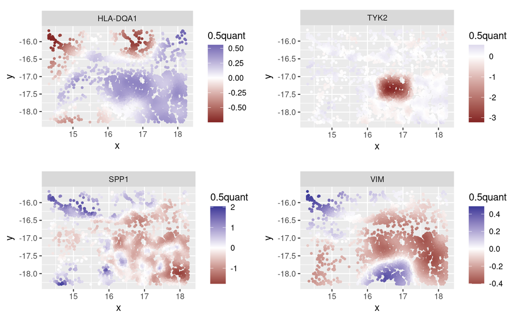

```r
cowplot::plot_grid(plotlist=
  lapply(
    split(results(de_inla_nb, targets = c("HLA-DQA1","TYK2","SPP1","VIM"))$spatial_random_effect,
          by="target"), function(xx){
            ggplot(merge(xx, modeldat,
                         by.x = c("x","y"), by.y = c("sdimx", "sdimy"), all.y = T),
                   aes(x,y, col= `0.5quant`)) +
              geom_point(cex=0.8) +
              scale_color_gradient2(midpoint = 0) +
              theme(legend.position = "right") +
              facet_wrap(~target) + coord_fixed()
  }), nrow = 2
)
```

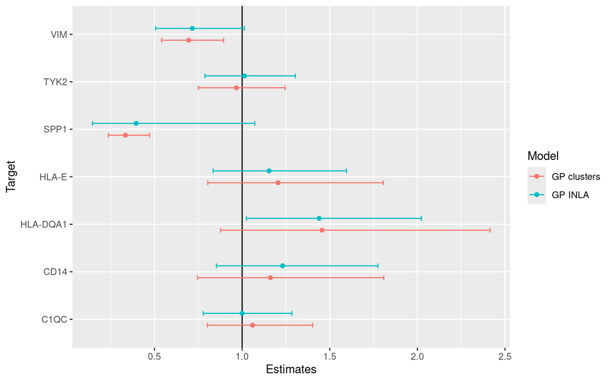

```r
results_inla <- results(de_inla_nb, variable="niche")$pairwise[contrast == "plasmablast-enriched stroma / tumor-stroma boundary"]
colnames(results_inla)[4:6] <- c("lb","est","ub")
results_GPclust <- results(de_GPclust_nb, variable="niche")$pairwise[contrast == "plasmablast-enriched stroma / tumor-stroma boundary"]
# obtaining bonferroni correct confidence intervals
results_GPclust$lb <- exp(log(results_GPclust$ratio) - qnorm(1-(0.025/num_genes)) * results_GPclust$SE)
results_GPclust$ub <- exp(log(results_GPclust$ratio) + qnorm(1-(0.025/num_genes)) * results_GPclust$SE)



compar_inla <- rbindlist(list(results_GPclust[,.(target, contrast, est=fold_change, lb, ub, model = "GP clusters")]
                              ,results_inla[,.(target, contrast, est, lb, ub, model = "GP INLA")])
                         )

ggplot(compar_inla, aes(y = target, x = est, col = model)) +
  geom_vline(xintercept = 1) +
  labs(x = "Estimates", y = "Target", col = "Model") +
  geom_point(position = position_dodge(0.5)) +
  geom_errorbar(aes(xmin = lb, xmax = ub),
                  position = position_dodge(0.5), width = 0.2)
```

### Trying different priors

One important aspect of bayesian statistics is the choice of priors. Priors are set for the range $\rho$ and standard deviation $\sigma$ parameters of the Matern matrix. The priors are specified based on the construction by Fuglstad, et al. (2016), in which we assume $P(\rho<\rho_0)=p_\rho$ and $P(\sigma>\sigma_0)=p_\sigma$, so we need to specify $(\rho_0, p_\rho)$ and $(\sigma_0, p_\sigma)$. The range parameters controls the range over which spatial correlation decays and needs to be accounted in the same scale of the data. In the spatial transcriptomics setting we expect that cells further away enough are spatially uncorrelated, so the range specifies the distance in which two cells would not be correlated. The variance parameter represents the marginal standard deviation of the process. When $\sigma=0$ there’s no random spatial effect, and as $\sigma$ increases it indicates more variability on the spatial effect. It is worth nothing that this parameter will depend on the choice of the distribution, since the scale of normalized and raw data changes.

If there’s no previous knowledge about the spatial correlation it is of good practice to choose very wide priors. By default, we first compute the average range of `x` and `y` coordinates of modeled cells, and set the priors for $rho$ as $P(\rho< avg_range_xy)=0.5$, and $P(\sigma>0.5)=0.5$. For this dataset, the average of x/y coordinate ranges is

```r
mean(diff(range(modeldat[["sdimx"]])), diff(range(modeldat[["sdimy"]]))) ## average range, used to set prior P(\rho < avg_range_xy) = 0.5
```

```
## [1] 3.93402
```

Other priors may be optimal or could be more carefully chosen and specified based on the dataset. For comparison, we show alternate specifications for priors, choosing a much different setting, where $P(\rho<0.1)=0.05$ and $P(\sigma>5)=0.05$.

```r
de_inla_nb2 <-
  smiDE::smi_de(assay_matrix = sem[["RNA"]]@counts
                ,metadata = modeldat
                ,formula = ~RankNorm(otherct_expr) + niche + offset(log(totalcounts))
                ,targets = analysis_genes
                ,family="nbinom2",
                ,pre_de_obj = pre_de_obj
                ,neighbor_expr_cell_type_metadata_colname = "cell_type"
                ,neighbor_expr_overlap_agg ="sum"
                ,neighbor_expr_totalcount_normalize = TRUE
                ,neighbor_expr_totalcount_scalefactor = totalcounts_scalefactors
                ,spatial_model = list(name="GP_INLA"
                                      ,prior.range.inlaprior = c(0.1, 0.05) # P(range < 0.1) = 0.05
                                      ,prior.sigma.inlaprior = c(5, 0.05)   # P(sigma > 5) = 0.05
                                      ,quantiles = c(0.025/num_genes, 0.5, 1-0.025/num_genes)
                                      ,x_coord_col = "sdimx", y_coord_col = "sdimy"
                                     )
                ,nCores=1
  )
```

Below we analyze estimates and credible intervals obtained with each prior, for comparison between plasmablast-enriched stroma and tumor-stroma boundary. We note that there’s a slight difference between estimates and bounds obtained with each prior. In particular we note that gene SPP1 was found to be significant with the new prior, similarly to GP clusters, and the bounds for this gene changed the most, whereas bounds for other genes are incredibly similar. Therefore, priors need to be chosen carefully as they can influence results, especially for smaller sample sizes.

```r
results_p1 <- results(de_inla_nb,  variable="niche")$pairwise[contrast == "plasmablast-enriched stroma / tumor-stroma boundary"]
colnames(results_p1)[4:6] <- c("credible_lb","estimate","credible_ub")
results_p2 <- results(de_inla_nb2, variable="niche")$pairwise[contrast == "plasmablast-enriched stroma / tumor-stroma boundary"]
colnames(results_p2)[4:6] <- c("credible_lb","estimate","credible_ub")


compar <- rbindlist(list(
  results_p1[,.(target, contrast, est = estimate,
                              lb = credible_lb,
                              ub = credible_ub
                              ,prior = "priors1")]
  ,results_p2[,.(target, contrast,
                 est = estimate,
                 lb = credible_lb,
                 ub = credible_ub
                 ,prior = "priors2")]
))

### comparison between priors
compar[order(contrast, target, prior)][]
```

```
##       target                                            contrast       est
##  1:     C1QC plasmablast-enriched stroma / tumor-stroma boundary 0.9996951
##  2:     C1QC plasmablast-enriched stroma / tumor-stroma boundary 1.0020893
##  3:     CD14 plasmablast-enriched stroma / tumor-stroma boundary 1.2308526
##  4:     CD14 plasmablast-enriched stroma / tumor-stroma boundary 1.2287988
##  5: HLA-DQA1 plasmablast-enriched stroma / tumor-stroma boundary 1.4393336
##  6: HLA-DQA1 plasmablast-enriched stroma / tumor-stroma boundary 1.4412440
##  7:    HLA-E plasmablast-enriched stroma / tumor-stroma boundary 1.1537719
##  8:    HLA-E plasmablast-enriched stroma / tumor-stroma boundary 1.1560843
##  9:     SPP1 plasmablast-enriched stroma / tumor-stroma boundary 0.3952731
## 10:     SPP1 plasmablast-enriched stroma / tumor-stroma boundary 0.3149083
## 11:     TYK2 plasmablast-enriched stroma / tumor-stroma boundary 1.0137884
## 12:     TYK2 plasmablast-enriched stroma / tumor-stroma boundary 1.0150428
## 13:      VIM plasmablast-enriched stroma / tumor-stroma boundary 0.7159008
## 14:      VIM plasmablast-enriched stroma / tumor-stroma boundary 0.7121444
##            lb        ub   prior
##  1: 0.7784567 1.2838100 priors1
##  2: 0.7802368 1.2870236 priors2
##  3: 0.8534122 1.7752251 priors1
##  4: 0.8522581 1.7717015 priors2
##  5: 1.0242266 2.0226792 priors1
##  6: 1.0256007 2.0253350 priors2
##  7: 0.8345283 1.5951407 priors1
##  8: 0.8366348 1.5975087 priors2
##  9: 0.1457285 1.0721377 priors1
## 10: 0.1166678 0.8499971 priors2
## 11: 0.7881036 1.3041016 priors1
## 12: 0.7891333 1.3056249 priors2
## 13: 0.5061511 1.0125712 priors1
## 14: 0.5038035 1.0066422 priors2
```

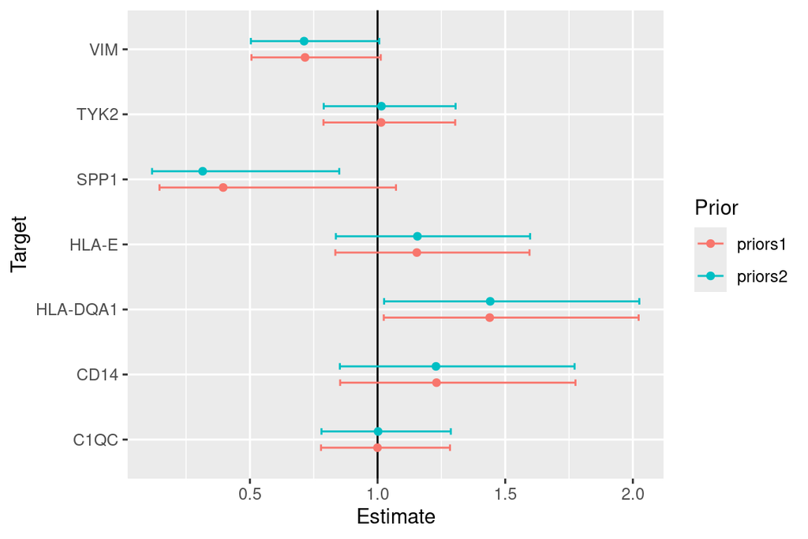

```r
ggplot(compar, aes(y = target, x = est, col = prior)) +
  geom_vline(xintercept = 1) +
  labs(x = "Estimate", y = "Target", col = "Prior") +
  geom_point(position = position_dodge(0.5)) +
  geom_errorbar(aes(xmin = lb, xmax = ub),
                    position = position_dodge(0.5), width = 0.2)
```